# FACTORS INFLUENCING SPECIES COMPOSITION IN TROPICAL LOWLAND RAIN FOREST: DOES SOIL MATTER? - Sollins - 1998 - Ecology - Wiley Online Library

[Ecology](https://esajournals.onlinelibrary.wiley.com/journal/19399170)

[Volume 79, Issue 1](https://esajournals.onlinelibrary.wiley.com/toc/19399170/1998/79/1) p. 23-30

[figure not shown]

Features

Full Access

# FACTORS INFLUENCING SPECIES COMPOSITION IN TROPICAL LOWLAND RAIN FOREST: DOES SOIL MATTER?

[Phillip Sollins](https://esajournals.onlinelibrary.wiley.com/authored-by/Sollins/Phillip),

First published: 01 January 1998

https://doi.org/10.1890/0012-9658(1998)079[0023:FISCIT]2.0.CO;2

Citations: 181

## Abstract

The soil properties most likely to influence species composition in lowland tropical rain forests are, in decreasing order of importance: P availability, Al toxicity, drainage, water-holding capacity, and availability of K, Ca, and Mg. A total of 18 studies were located in which species occurrence was studied in relation to such soil properties. Several of these report clear trends with soil physical properties, mainly drainage as affected by topographic position. Only three offer evidence for correlations with soil chemical properties. In all three, the study area spanned soils of very widely differing age and thus soil fertility. Failure to find correlations with chemical properties may be due to: lack of range in soil fertility across the sites studied, failure of soil test methods to measure availability of nutrients to plants, or temporal and spatial variability in soil properties.

Existing soil classification systems do not provide enough information on any particular soil to help establish relations between its chemical properties and plant distribution. Nonetheless, soils at ecological study sites must be classified if their nature and properties are to be made clear to others working worldwide. Traditional, largely subjective, soil-mapping techniques may reduce sampling needs by allowing stratification of soil and plant sampling by broad soil types. The mapping must be done, however, at a scale similar to the patchiness of the plant community (usually finer than 1:5000), something done in only 3 of the 18 studies located.

Correlative studies are only the first step in understanding causal relations between soil properties and plant species distribution. Next, nutritional, drainage, and water requirements must be established for individual species. Then field experiments must be set up to establish cause and effect.

## Introduction

To anyone not brought up in or around old-growth tropical rain forest, the diversity of tree species is at first quite beyond comprehension. Not only are there so many species—150 per hectare is not uncommon—but they seem to recur with no obvious pattern. Do patterns exist? If so, what controls them?

The possibility that soil factors might control species occurrence in tropical forests has long intrigued researchers. Soil chemical factors have been an especially favored target, probably because Al toxicity and lack of nutrients are often problems for tropical agriculture (Sanchez 1976). Here I review studies of effects of soil factors on species composition in old-growth lowland tropical forest, look for reasons why more definitive results have not come forth, and offer suggestions as to what might be done differently in the future.

Of the many chemical and physical properties of soils, which might be expected to most influence rain-forest species composition? Based on several excellent reviews of tropical soils and plant–soil relations (e.g., Sanchez 1976, Uehara and Gillman 1981, Högberg 1986, Grubb 1989, Richter and Babbar 1991) plus more recent primary literature, a reasonable set might be (in decreasing order of importance): P availability, Al toxicity, depth to water table, amount and arrangement of pores of different sizes, and availability of base-metal cations, micronutrients (e.g., B, Zn), and N.

Of these factors, I list N last because most lowland tropical soils are relatively N rich, although N availability often constrains productivity at tropical montane sites (Vitousek and Sanford 1986). Soil pH is important mainly because it varies inversely with Al toxicity and directly with base-metal cation availability, especially below about pH 5.3; pH, however, is much cheaper to measure than are cations or Al. Aluminium toxicity involves deleterious effects of soluble Al on root growth and function (e.g., Sanchez 1976, Robson 1989). Size distribution and arrangement of soil pores are important because they determine the soil’s capacity to supply moisture (the change in water content between field capacity and wilting point), water infiltration and drainage rates, and aeration, all of which strongly affect plants.

Many of these soil properties co-vary across the tropical landscape, leading to problems in sampling and in interpreting results. To understand the causes and nature of this covariation, it helps to understand the factors that in turn control the soil properties. These factors are often grouped into five categories: age, parent material, climate, topography, and biota. Many of these also act indirectly through each other (Fig. 1). Any attempt to study these factors must take into account the spatial scale at which their effects are best seen in the humid tropics. A reasonable ranking of the five factors in terms of decreasing coarseness of the spatial scale of their effects might be: macroclimate > land surface age and parent material > microclimate and topographic position > biota (including people).

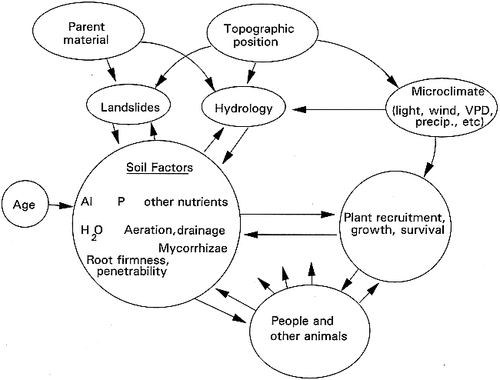

**Figure 1**

Direct and indirect controls on soil formation in the humid tropics. (VPD = vapor-pressure default.)

I found 18 studies in which occurrence of individual species was studied in relation to soil properties (Table 1). Many more studies report species diversity but not occurrence of individual species. Across the 18 studies in Table 1, trends with soil physical properties were clear. For example, many studies reported trends in species composition with soil drainage regime (Baillie et al. 1987, Ashton and Hall 1992, Basnet 1992, Johnston 1992, ter Steege et al. 1993). Work by Lescure and Boulet (1985) deserves special note as they mapped the soil mantle in three dimensions across their entire 17-ha study area, focusing specifically on slope position and drainage.

Table 1. Studies relating tree species distribution to soil properties in the humid tropics. Chemical properties refer to surface soil. “?” means the study was unclear with respect to this item; “nd” means data were not supplied in the original study.

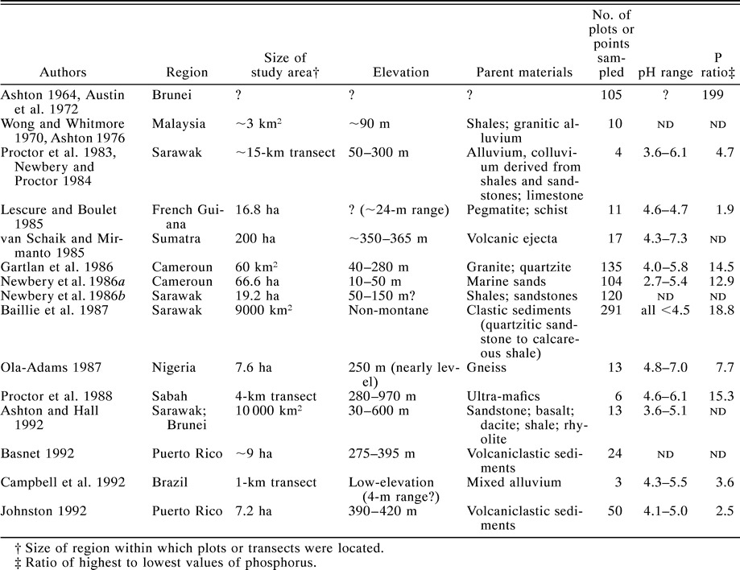

Relations between soil chemical factors and species distribution have proven more elusive. Of the 18 studies in Table 1, three reported relations between nutrient availability and species composition. Ashton and Hall (1992) found that a guild of fast-growing tree species was more common on the more P- and cation-rich soils. Clark et al. (1995) found strong trends in distribution of some (but not all) palm species with landscape position, at least some of which seemed due to soil chemical status (e.g., P, Al, pH) rather than drainage regime. As the authors point out, however, both field and laboratory experiments and better understanding of the physiological needs of the species will be needed to separate the roles of moisture and drainage regimes and of soil chemical factors.

Van Schaik and Mirmanto (1985) provide perhaps the clearest example of correlations between nutrient availability and specific plant processes and patterns. Working on six alluvial terraces formed when successive eruptions of the Toba volcano temporarily blocked a valley in Sumatra, they used the large differences in age (and thus pH) of the soil on the terraces to index soil fertility. They found that litter and fruit production decreased with decreasing pH, whereas forest stature and life-span increased. Although species composition was not studied in detail, the authors mention anecdotally (p. 197) that “The Dipterocarpaceae are clearly more abundant on the [less fertile] higher terraces and mountain slopes than on the [more fertile] lower terraces.” Given this pattern, and the strong relation found between pH and various plant processes, effects of soil chemical factors on species composition are to be expected.

Why have relations between species occurrence and soil chemical factors been so hard to find? Answers, I believe, lie in the inherent limitations of correlative approaches, in the problems associated with measuring availability of nutrients to plants, and in the inadequacies of most efforts at soil mapping and classification.

## Correlative vs. Experimental Approaches

Correlative results are inherently difficult to interpret. First, many interacting variables are involved, including many non-chemical factors. Experiments in which soil chemical factors are altered in replicated design would be much more definitive, but few such studies have been done. Harcombe (1977), Tanner et al. (1990, 1993) and Raich et al. (1996) measured effects of fertilization on growth and productivity. Long-term studies of effects of fertilization on species composition are feasible but, to my knowledge, have not been attempted. Second, cause and effect are hard to separate. Plants gradually alter the soils in which they grow (e.g., Montagnini and Sancho 1990) making it very hard to tell whether plants prefer certain kinds of soil or create them (Binkley 1995). Thus, even if experimental studies are set up, it will be important to measure the processes controlling soil chemical (and physical) properties if the plant–soil feedback is to be untangled.

Significant correlations are hard enough to interpret; lack of correlation proves virtually nothing. Poor correlation between two variables may be due as easily to confounding factors, which create spatial and temporal noise, as to any lack of causal relation. In addition, lack of correlation can reflect insufficient range in the independent variable. It is interesting in this regard to look at the 18 studies in Table 1, especially with regard to pH, which is a reasonably good overall measure of tropical soil fertility. The range spanned in the studies varied from 0.1 (Lescure and Boulet 1985) to 3.0 pH units (van Schaik and Mirmanto 1985). Early, less quantitative work in British Guiana (Davis and Richards 1934) and Peninsular Malaysia (Wong and Whitmore 1970) spanned very large ranges in soil morphology. Much of the more recent work seemed to span smaller ranges in soil properties, although there were notable exceptions (e.g., van Schaik and Mirmanta 1985). The pH range did not, in general, increase with the size of the study area; thus increasing the pH range may require a targeted effort based on knowledge of soils and soil-formation processes, not just a larger study area.

The range of soil pH did, however, influence the strength of correlations. Where researchers worked with large ranges in soil chemical properties, they found large effects on plant community characteristics. This suggests that one reason why relations between soil chemical properties and plant community characteristics have been so elusive is that the little remaining intact tropical forest is restricted mainly to the least fertile land. The most fertile tropical soils have long been in continuous agriculture, and many of the less fertile areas are being used now for intermittent agriculture and wood production. Thus plant ecologists may be attempting to discern effects of very subtle differences in soil chemical properties on plants.

## Measuring Availability of Nutrients to Plants

A second reason why so few studies showed clear relations between nutrient availability and species composition may be that relations between plant processes (e.g., establishment, growth, survival, and reproductive success) and soil chemical properties are still poorly understood. There are two facets to this problem. First, our chemical-extraction assays of nutrient availability do not really measure availability to plants. This is especially true for P, which so often limits plant growth in the humid tropics. For example, the various P-extraction methods give very different results, often ranking soils quite differently. Fig. 2 illustrates the lack of correlation between two commonly used measures of P availability. At La Selva, Costa Rica, bioassays of plant response to fertilizer (Denslow et al. 1987, P. Sollins and G. P. Robertson, *unpublished data*) indicate a consistent decrease in fertility with increasing terrace age. Such a decrease can be seen in Fig. 2 for one common measure of P availability but not for another. In Table 1, I chose to report the ratio of highest to lowest P value, rather than the actual values, because methods for P extraction were inconsistent. In fact, of the 10 studies in Table 1 that included P data, three did not describe the P-extraction method at all. Bioassays resolve many of the problems with interpretation of soil assays, but even bioassays are problematic since using mature trees is largely impractical, and seedlings cannot be assumed to respond as do large trees.

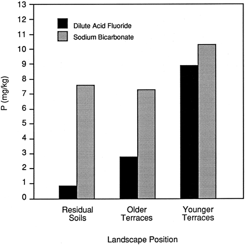

**Figure 2**

Soil variability, both spatial and temporal, is a second facet of the problem. Despite much work on spatial variation in soil properties we still don’t know how to sample the rooting zone of even a sapling, much less a canopy emergent. Soil properties vary markedly over distances of centimeters, yet most analyses cannot be done with samples larger than a few cubic centimeters. Larger volumes of soil can be collected, then composited and subsampled, but as the volume collected increases so does the likelihood of disturbing the plant. Moreover, there is no certainty that average values of soil properties will correlate well with plant performance, as many relations involve nonlinearities and thresholds.

Problems of temporal variability can be equally severe and are less often recognized. In work in Costa Rica, G. P. Robertson and I found that, although some soil properties, such as total C and N stores, remained relatively constant from week to week and month to month, other properties, such as pH and levels of exchangeable cations, changed radically (Fig. 3). Results from Cameroun exemplify the interpretation problems that can be caused by such temporal variability. Working first in the wet season, Gartlan et al. (1986) and Newbery et al. (1986*a*) reported that various Caesalpinoideae were most abundant where levels of available P were low. Returning later to sample the same areas in the dry season, Newbery et al. (1988) found that the P pattern had reversed and was now higher where it had been lower before. This reversal in soil pattern highlights both the problem of temporal variability in soil properties and the dangers inherent in trying to infer causal relations from correlative studies.

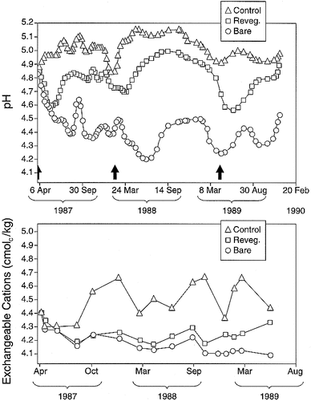

**Figure 3**

Variation through time in pH and exchangeable cations (K, Mg, and Ca; in units of centimoles of charge, cmol<sub>c</sub>, per kilogram) in the 0–15-cm depth layer of an Oxic Humitropept under abandoned pasture at La Selva, Costa Rica (G. P. Robertson and P. Sollins, *unpublished data*). Vegetation treatments were: bare fallow (hand weeded), annual harvest (reveg.), and control. Arrows indicate harvest dates. Cations were extracted overnight in a 0.5-mol solution of NaCl (1:5 soil:water suspension) with gentle shaking; pH was measured in 1:5 soil:water suspension (data smoothed). Each point is the mean of four replicates; all standard errors were small relative to means. See Sollins and Radulovich (1988) for site description.

Have plantation foresters or tropical agronomists been any better able to take advantage of soil-nutrient assays than forest ecologists? Evans (1992), in a review of some 900 studies of tropical plantation forestry, listed only eight that related tree growth to soil test results, and none in which fertilizer recommendations were keyed to soil properties. Tropical agronomy has seen more work along these lines. Lins and Cox (1989), for example, reported great success in keying P fertilization of soybean to soil test results across seven Brasilian soils, all well weathered but varying markedly in clay content. Better progress is to be expected with crop plants than with trees, because the former reach harvest age much faster, markedly decreasing the time needed to get experimental results. Even so, much agronomic research does not relate soil factors to physiological needs of plants. An unpublished dissertation by Vander Zaag (1979), for example, continues to be cited widely because it is one of the few data sets linking growth of tropical crop plants to nutrient levels in the soil solution.

In summary, I think there is reason to believe that soil factors, even chemical ones, influence tree species distribution, but finding such relations will require more intensive soil sampling keyed to understanding of the patterns and causes of spatial and temporal variation in soil properties and to knowledge of the physiological needs of individual plant species.

## Relevance of Soil Classification

Plant ecologists may ask why soil classification is not of more help to them in examining relations between soil properties and species occurrence. A major reason is that soil-classification systems are designed to meet the needs of a wide range of users and in the process probably meet no single need as well as they might. In other words, given uses as diverse as agriculture and road building, soil-classification systems can hardly be expected to provide the best possible prediction of either crop growth or slope stability.

In fact, however, much information on nutrient availability can be gleaned from a soil’s classification. Easiest to obtain is the tendency for P sorption, useful because P sorption strongly influences P availability. To extract this information from the classification of a soil, however, requires understanding the relation between soil mineralogy and classification.

Clay mineralogy, the types and amounts of clays in a soil, is the prime determinant of a soil’s chemical and physical properties, and thus also its biological properties (Sanchez 1976, Uehara and Gillman 1981). Mineralogy controls physical structure by determining in large measure the extent to which clay particles aggregate, which in turn determines the hydraulic properties of a soil. Well-aggregated soils are highly productive—they drain rapidly through the spaces between aggregates yet retain large amounts of plant-available water in small pores within aggregates (Radulovich et al. 1992). Mineralogy also strongly influences cation-exchange capacity (CEC) and almost completely controls P-sorption capacity (Sollins et al. 1988). For example, soils rich in kaolinite and Fe and Al oxides have low CEC, thus little ability to retain cations, especially at low pH. The oxide-rich soils, though not the kaolinitic ones, tend to sorb large amounts of P, releasing it only slowly and keeping available P at low (but steady) levels.

Some information about the mineralogy of a soil can often be extracted from its classification. Thus, most Ultisols are kaolin-rich whereas most Oxisols are oxide-rich. A Gibbsihumox is so called because it is rich in gibbsite Al(OH)<sub>3</sub> and, incidentally, organic matter (thus the “hum” designation). Fine-textured Andisols contain allophane, the most strongly P sorbing of all the clay and clay-like minerals (Sollins et al. 1988).

Additional information about a soil’s mineralogy may come from knowledge of its genesis. In particular, the elemental composition of the parent material influences strongly the types of clays and clay-like minerals that will develop as the soil ages (Birkeland 1984, Sollins et al. 1988). Thus, if we know the parent material and age of the soils in question and how these vary across the landscape, we may be able to make inferences about mineralogy and thus nutritional factors affecting plants. Most soil-classification systems, however, are not designed to provide information about soil genesis. Soil Taxonomy, one of the most widely used systems, was keyed intentionally to the current properties of a soil, not to its history. This is because focusing on current properties avoids the need for detailed geological and geomorphological studies in order to classify a soil. This decision makes sense even for ecologists–plants do not respond to a soil’s history, after all, but rather to its current properties. Nonetheless, much information about soil genesis is often available from soil scientists who have mapped soils in the area in question, and from others who may be familiar with areas that are geologically and climatically similar. Such scientists can be an invaluable source for information on soil mineralogy, and thus on patterns of soil chemical and physical properties.

Of course mineralogy is best established not by deduction based on soil genesis and geomorphic or climatic setting, but rather by laboratory procedure. Determining mineralogy, however, involves expensive, highly technical analyses (x-ray diffraction, chemical extractions, microscopy) and thus is often not done. Moreover, due to cost constraints, nearly all soil survey and classification is based on very limited spatial sampling, the dangers and limitations of which have already been noted.

Although soil-classification systems may not relate as well as we might like to fertility and other soil factors affecting plants, it is still critical that plant ecologists describe and classify the soils at their study sites. The soil-classification systems provide a way to view a soil and its properties in relation to soils worldwide, much as knowing family, order, class, and phylum provide a way to view a biological species in relation to others worldwide.

## Relevance of Soil Mapping

A soils map can provide an effective basis for stratifying soil and plant sampling. To be so used, however, the scale of the soil map must match that of the patterns in soil factors that are thought to control plant distribution. Thus, to examine effects of slope position on plant-community characteristics requires very detailed soil mapping (certainly 1:5000, perhaps much finer), whereas to examine effects of macroclimate, the current United Nations Food and Agriculture Organization’s world soils map at 1:5000000 (FAO 1990) may be quite adequate. Many studies (Ashton 1964, Poore 1968, Wong and Whitmore 1970, and Proctor et al. 1983) used coarse-scale soils maps in which the smallest map units were larger than the vegetation plots. Such coarse-scale maps inevitably obscure fine-scale variation in soil properties, variation that may be important to understanding patterns of species distribution. For example, at Pasoh, Malaysia, Ashton (1976) found substantial soil heterogeneity within several plots that had been described by Wong and Whitmore (1970) as being located on single soil types; one, for example, extended from an alluvial terrace onto an adjacent ascending slope. Clearly, the available soil maps were of little use in explaining within-plot patterns of species distribution. The spatial scale of the maps must match the questions being asked.

Soil sampling was not based on soil survey in most of the studies in Table 1. Instead, single or composite soil samples were collected for each of a series of vegetation plots that were located on transects or grids or were chosen from some preexisting set of plots. A few researchers located plots using a coarse-scale soils map (e.g., Johnston 1992). Only Lescure and Boulet (1985), van Schaik and Mirmanto (1985), and Clark et al. (1995) worked from a fine-scale soil survey (finer than 1:5000) that was described either in their article or in other published reports so that the mapping scale and accuracy could be evaluated. ter Steege (1993) used a fine-scale soils map but details of the soil survey have not been published.

For van Schaik and Mirmanto (1985) and Clark et al. (1995), availability of a detailed soils map allowed the soil and plant measurements to be stratified according to soil factors likely to affect plant-community characteristics. Interestingly, in both cases the soils maps not only delimited areas of similar soils, but also provided, at least implicitly, a hypothesis as to the geomorphic and geologic causes of that soil pattern. In general, I believe that a preliminary soil mapping at a scale of 1:5000 or finer will greatly reduce the effort required to study plant–soil relations in tropical rain forest, but this belief has not been tested quantitatively.

## Conclusions and Outlook

How much help can soil science offer tropical-plant ecology? The studies to date are probably not a fair test. In most, the soil survey was too coarse-scale to be of help. Indeed, in the three cases in which the scale of soil survey was fine enough, the survey helped tremendously in designing sampling strategy and interpreting results. Two of these three studies were at sites, La Selva and the Toba valley, that contain infertile upland areas adjacent to young alluvial terraces that together span a wide range of chemical and physical soil characteristics. Although species sorting by soil type was not studied in the older, more uniformly infertile soils, species sorting between upland and terrace soils, and between the various terraces, was clearly evident.

Collaboration between soil science and tropical-plant ecology has benefitted both, but there is room for improvement. Each discipline could be more aware of the needs and limitations of the other. Soil scientists could be more candid about limitations of their classification systems and mapping techniques, especially in mountainous or dissected terrain. Interpreting processes of soil genesis in the areas they map would make information on soil mineralogy more accessible, and thus their findings more useful, to ecologists. Plant ecologists would benefit from learning more about soil science, geomorphology, and geology. Although soil-science terminology seems forbidding, it is no worse than that of plant anatomy and systematics. Conversely, by learning to identify more plant species, and by learning what is known of their nutritional and water requirements, soil scientists may be better able to use vegetation patterns to make initial guesses at soil boundaries and be better able to suggest soil factors that might affect plant species distributions.

Last, I would reiterate that correlation studies by themselves will never provide all the answers that we seek. We need also to study the nutritional, drainage, and water requirements of those tree species whose occurrence does correlate with soil factors. Then, based on such information, field experiments must be set up to establish cause and effect.

## Acknowledgments

I thank D. Binkley, D. A. Clark, D. B. Clark, K. Johnson, T. Spies, P. Vitousek, and R. Yanai for their many insightful comments.

## Citing Literature

[figure not shown]

[Volume79, Issue1](https://esajournals.onlinelibrary.wiley.com/toc/19399170/1998/79/1)

January 1998

Pages 23-30